# Creating inverse functions

Mr. Worley

Thu Aug 28

# Entrance Ticket

Entrance ticket on Canvas: [ET_08_28](https://bart.instructure.com/courses/2110/quizzes/3142)

# Note: fraction bars have implied parentheses.

The fraction bar has implied parentheses.
$$\frac{3+4}{5+6}~~=~~(3+4)\div(5+6)$$

# Find inverse of function defined with algebraic expression

- We begin with simple functions that can be understood as taking an input and then applying a series of elementary additions, subtractions, multiplications, and divisions by integers.
- Find the inverse:
  $$f(x)~=~9\cdot\left(\frac{2x+7}{5}-8\right)+3$$
- Start by identifying the sequence of operations applied to $x$. (Describe function $f$.)
  1. Multiply by 2
  2. Add 7
  3. Divide by 5
  4. Subtract 8
  5. Multiply by 9
  6. Add 3
- Replace $f(x)$ with $y$… for… simplicity.
  $$y~=~9\cdot\left(\frac{2x+7}{5}-8\right)+3$$
- Swap $x$ and $y$. So, now $y$ represents the inverse function.
  $$x~=~9\cdot\left(\frac{2y+7}{5}-8\right)+3$$
- Undo those operations in reverse order to solve for $y$.
  1. Subtract 3.
     $$x-3~=~9\cdot\left(\frac{2y+7}{5}-8\right)$$
  2. Divide by 9.
     $$\frac{x-3}{9}~=~\frac{2y+7}{5}-8$$
  3. Add 8.
     $$\frac{x-3}{9}+8~=~\frac{2y+7}{5}$$
  4. Multiply by 5.
     $$5\left(\frac{x-3}{9}+8\right)~=~2y+7$$
  5. Subtract 7.
     $$5\left(\frac{x-3}{9}+8\right)-7~=~2y$$
  6. Divide by 2.
     $$\frac{5\left(\frac{x-3}{9}+8\right)-7}{2}~=~y$$
- Return to function notation. Remember, after the swap, $y$ is the INVERSE function.
  $$\frac{5\left(\frac{x-3}{9}+8\right)-7}{2}~=~f^{-1}(x)$$
- Equality is commutative. We tend to put the function notation on left side.
  $$f^{-1}(x)~=~\frac{5\left(\frac{x-3}{9}+8\right)-7}{2}$$

# Simple example

Find the inverse:
$$f(x)~=~
\frac{7+x}{3}$$

- Let’s use the standard approach.
- First, get rid of function notation.
  $$y=\frac{7+x}{3}$$
- Swap $x$ and $y$.
  $$x=\frac{7+y}{3}$$
- At this point, the $y$ represents the inverse function. Solve for $y$. (Get $y$ by itself.)
- Multiply both sides by 3.
  $$3x=7+y$$
- Subtract 7 from both sides.
  $$3x-7=y$$
- Return to function notation. Because we swapped in the beginning, $y$ is the inverse function.
  $$3x-7=f^{-1}(x)$$
- Use commutative property of equality. We typically put the function notation on the left side.
  $$f^{-1}(x)~=~3x-7$$

# Simple example 2

Find the inverse:
$$f(x)~=~
8\left(4+\frac{x}{9}\right)$$

# Inverse function from table

Consider the function $f$ defined by the table below.

| $x$ | $f(x)$ |
| --- | --- |
| 1 | 5 |
| 2 | 3 |
| 3 | 1 |
| 4 | 2 |
| 5 | 4 |

What values would you use to fill the inverse function’s table?

| $x$ | $f^{-1}(x)$ |
| --- | --- |
| 1 |  |
| 2 |  |
| 3 |  |
| 4 |  |
| 5 |  |

# Inverse function from table

Consider the function $f$ defined by the table below.

| $x$ | $f(x)$ |
| --- | --- |
| 1 | 5 |
| 2 | 3 |
| 3 | 1 |
| 4 | 2 |
| 5 | 4 |

What values would you use to fill the inverse function’s table?

| $x$ | $f^{-1}(x)$ |
| --- | --- |
| 1 | 3 |
| 2 | 4 |
| 3 | 2 |
| 4 | 5 |
| 5 | 1 |

Notice you swap the two columns, and then sort the first column. We are still “swapping $x$ and $y$”.

# Inverse function from table

Consider the function $f$ defined by the table below.

| $x$ | $f(x)$ |
| --- | --- |
| 1 | 4 |
| 2 | 1 |
| 3 | 2 |
| 4 | 5 |
| 5 | 3 |

What values would you use to fill the inverse function’s table?

| $x$ | $f^{-1}(x)$ |
| --- | --- |
| 1 |  |
| 2 |  |
| 3 |  |
| 4 |  |
| 5 |  |

# Inverse function from curve

Let function $f$ be defined by the (piece-wise linear) curve shown below.

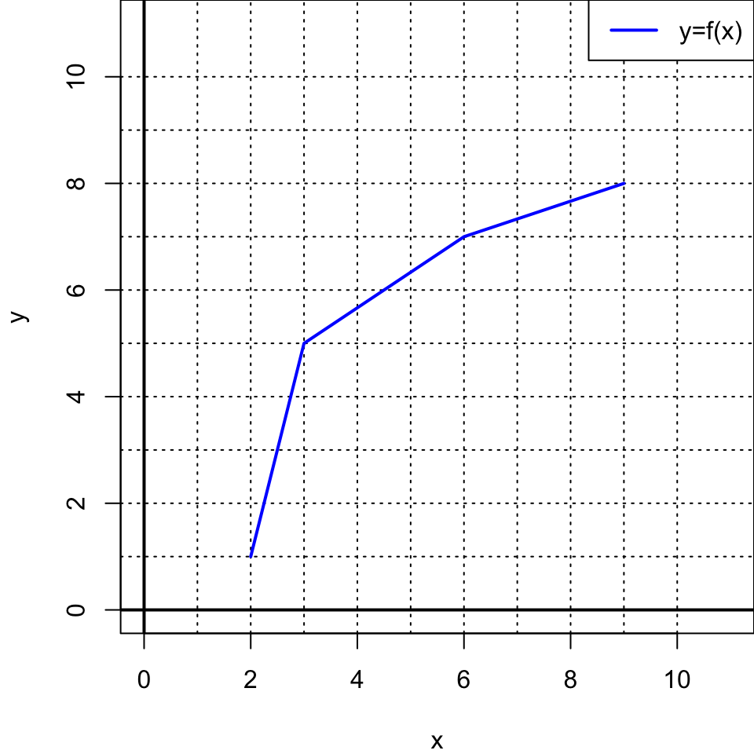

- How to find the inverse function’s curve?
- “SWAP $x$ AND $y$”
- The curve reflects over the $y=x$ line (the 45° line).
- Find the coordinates of the vertices:
  $$(2,1)~~~(3,5)~~~(6,7)~~~(9,8)$$
- Swap the coordinates of the vertices:
  $$(1,2)~~~(5,3)~~~(7,6)~~~(8,9)$$
- Draw a new curve connecting those new coordinates.

# Inverse function from curve

The original function $f$ and the inverse function $f^{-1}$ are mirror reflections over the $y=x$ line. This is because we “swap $x$ and $y$.”

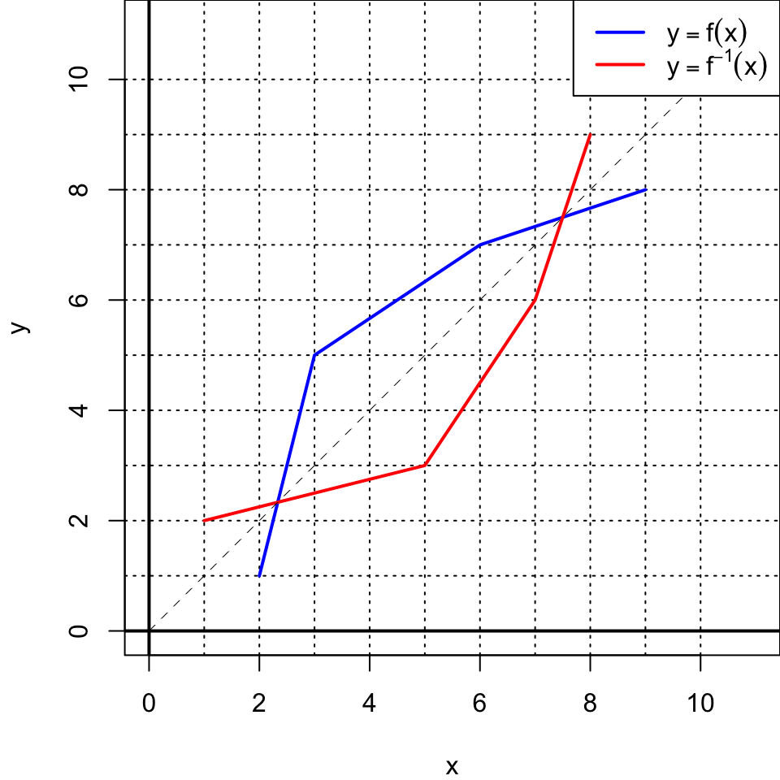